# Univariate Models HW Assignment

```r
#Anova and Summary generate same p-value

#modeling for abies, looking at all variables
abies_mod_lm <- lm(cover~ ., data=abies)
Anova(abies_mod_lm, type=3)
```

```
## Anova Table (Type III tests)
##
## Response: cover
##             Sum Sq  Df  F value    Pr(>F)
## (Intercept)  59.64   1  70.4167 2.501e-16 ***
## elev         98.13   1 115.8739 < 2.2e-16 ***
## tci           2.11   1   2.4895   0.11505
## streamdist    3.98   1   4.6951   0.03057 *
## disturb      28.40   3  11.1771 3.545e-07 ***
## beers         1.50   1   1.7679   0.18406
## Residuals   614.85 726
## ---
## Signif. codes:  0 '***' 0.001 '**' 0.01 '*' 0.05 '.' 0.1 ' ' 1
```

```r
summary(abies_mod_lm)
```

```
##
## Call:
## lm(formula = cover ~ ., data = abies)
##
## Residuals:
##     Min      1Q  Median      3Q     Max
## -1.5809 -0.4502 -0.0420  0.2346  6.9968
##
## Coefficients:
##                 Estimate Std. Error t value Pr(>|t|)
## (Intercept)   -1.5705179  0.1871566  -8.391 2.50e-16 ***
## elev           0.0013315  0.0001237  10.764  < 2e-16 ***
## tci            0.0255969  0.0162231   1.578 0.115046
## streamdist     0.0004553  0.0002101   2.167 0.030574 *
## disturbLT-SEL  0.3248142  0.0941853   3.449 0.000596 ***
## disturbSETTLE  0.5408814  0.1311418   4.124 4.15e-05 ***
## disturbVIRGIN  0.5584644  0.1082404   5.159 3.20e-07 ***
## beers         -0.0675883  0.0508326  -1.330 0.184059
## ---
## Signif. codes:  0 '***' 0.001 '**' 0.01 '*' 0.05 '.' 0.1 ' ' 1
##
## Residual standard error: 0.9203 on 726 degrees of freedom
## Multiple R-squared:  0.2478, Adjusted R-squared:  0.2406
## F-statistic: 34.17 on 7 and 726 DF,  p-value: < 2.2e-16
```

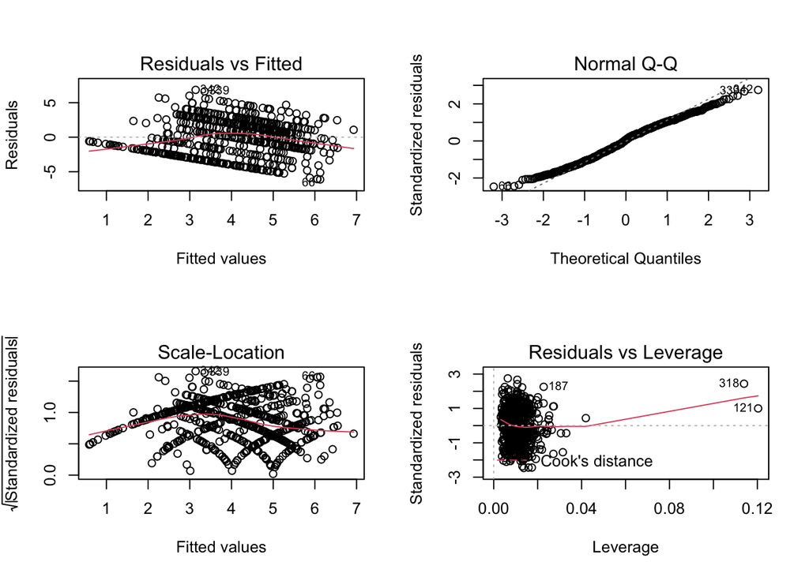

```r
#Anova and Summary also generate same p-value


#check normality
par(mfrow = c(2, 2))
plot(acer_mod_lm) #check for normality, Q-Q looks good, points pretty much normally distributed
```

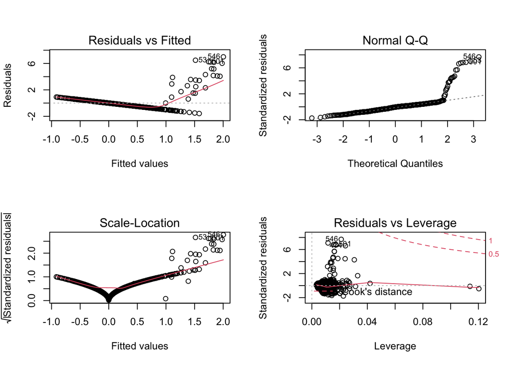

```r
plot(abies_mod_lm) #check for normality, Q-Q seems a little crazy, would look better if data was further subset-ed to use only points where abies (fir) were present
```

```r
#use predict function
xrange = range(trees$elev)
drange = range(trees$disturb)
new_obs = data.frame(elev = xrange, tci = xrange, streamdist = xrange, disturb = drange, beers = xrange)
str(new_obs)
```

```
## 'data.frame':    2 obs. of  5 variables:
##  $ elev      : num  267 1992
##  $ tci       : num  267 1992
##  $ streamdist: num  267 1992
##  $ disturb   : chr  "CORPLOG" "VIRGIN"
##  $ beers     : num  267 1992
```

```r
acer_predict <- predict(acer_mod_lm, newdata = new_obs, interval = 'confidence')

abies_predict <- predict(abies_mod_lm, newdata = new_obs, interval = 'confidence')

acer_predict
```

```
##         fit        lwr        upr
## 1  -136.511  -213.6878  -59.33418
## 2 -1076.492 -1655.5766 -497.40661
```

```r
abies_predict
```

```
##         fit        lwr       upr
## 1 -12.29309  -40.68935  16.10318
## 2 -81.09965 -294.16695 131.96765
```

For each species address the following additional questions:

- how well does the exploratory model appear to explain cover?

Acer: The exploratory model’s adjusted r-squared value is 0.17, indicating that 17% of the variability observed in cover is explained by the model. Abies: The exploratory model’s adjusted r-squared value is 0.24, indicating that 24% of the variability observed in cover is explained by the model.

- which explanatory variables are the most important?

Abies: Elevation, stream distance and disturbance all generated statistically significant results. Based on the summary, function, elevation had the largest relative effect size (t-value = 10.764), and based on the Anova elevation had a large f-value (115.87), so we would again argue that makes it the most important variable.

- do model diagnostics indicate any problems with violations of OLS assumptions?

Acer: Using plot(acer_mod_lm), the residuals vs. fitted and the Scale-Location graphs show some strange geometric patterns, which indicates issues with homoscedasticity, likely rooted in the rounding of cover to whole numbers. The Q-Q plot shows that the points are pretty much normally distributed, except for a few points that I don’t think warrant concern. The Residuals vs Leverage graph indicates that are large outliers that are having a disproportionate effect on the regression (at least points 318 and 121).

Abies: Using plot(abies_mod_lm), the residuals vs. fitted and Scale-Location graphs indicate issues with homoscedasticity. The Q-Q plot shows that errors are not normally distributed and the Residuals vs Leverage graph indicates that are large outliers that are having a disproportionate effect on the regression. However, the data could be cleaned up by further subsetting the Abies data to exclude data points where cover = 0.

```r
##notes for violations of OLS assumptions

#how to interpret homoscedasticity from left two graphs??: looking for evenly scattered points, hopefully no spikes (outliers) #there are/are not large outliers that are having a disproportionate effect on the regression.

#residuals/error are normally distributed (q-q) plot

#residuals vs leverage plot: related to homoscedasticity, looking for points to be evenly scattered/no outliers
```

- are you able to explain variance in one species better than another, why might this be the case?

For Abies, 24% of the variability observed in the target variable (cover) was explained (adjusted r^2 = 0.2406) while in Acer 17% of the variability observed in the target variable was explained by the model (adjusted r^2 = 0.1726). This might be the case because Acer is a habitat generalist that exists in numerous quantities at lower and mid elevations, while Abies tends to reside at higher elevations.

2. You may have noticed that the variable cover is defined as positive integers between 1 and 10. and is therefore better treated as a discrete rather than continuous variable. Re-examine your solutions to the question above but from the perspective of a General Linear Model (GLM) with a Poisson error term (rather than a Gaussian one as in OLS). The Poisson distribution generates integers 0 to positive infinity so this may provide a good first approximation. Your new model calls will look as follows:

```r
#GLM

#modeling for acer, looking at all variables
acer_mod_poi <- glm(cover ~ ., data=acer, family='poisson')
Anova(acer_mod_poi, type=3)
```

```
## Analysis of Deviance Table (Type III tests)
##
## Response: cover
##            LR Chisq Df Pr(>Chisq)
## elev        171.549  1  < 2.2e-16 ***
## tci          14.411  1  0.0001469 ***
## streamdist    1.451  1  0.2283874
## disturb      12.521  3  0.0057946 **
## beers        12.175  1  0.0004844 ***
## ---
## Signif. codes:  0 '***' 0.001 '**' 0.01 '*' 0.05 '.' 0.1 ' ' 1
```

```r
summary(acer_mod_poi)
```

```
##
## Call:
## glm(formula = cover ~ ., family = "poisson", data = acer)
##
## Deviance Residuals:
##     Min       1Q   Median       3Q      Max
## -3.6436  -1.4922   0.0961   0.8796   3.1435
##
## Coefficients:
##                 Estimate Std. Error z value Pr(>|z|)
## (Intercept)    2.593e+00  1.029e-01  25.211  < 2e-16 ***
## elev          -9.158e-04  7.139e-05 -12.828  < 2e-16 ***
## tci           -3.415e-02  9.271e-03  -3.683 0.000230 ***
## streamdist     1.351e-04  1.117e-04   1.209 0.226518
## disturbLT-SEL -1.254e-01  5.027e-02  -2.495 0.012603 *
## disturbSETTLE -2.352e-01  6.801e-02  -3.458 0.000544 ***
## disturbVIRGIN -1.020e-01  6.301e-02  -1.619 0.105544
## beers         -9.515e-02  2.725e-02  -3.491 0.000480 ***
## ---
## Signif. codes:  0 '***' 0.001 '**' 0.01 '*' 0.05 '.' 0.1 ' ' 1
##
## (Dispersion parameter for poisson family taken to be 1)
##
##     Null deviance: 1917.4  on 733  degrees of freedom
## Residual deviance: 1660.1  on 726  degrees of freedom
## AIC: 3651.9
##
## Number of Fisher Scoring iterations: 5
```

```r
#modeling for abies, looking at all variables
abies_mod_poi <- glm(cover~ ., data=abies, family='poisson')
Anova(abies_mod_poi, type=3)
```

```
## Analysis of Deviance Table (Type III tests)
##
## Response: cover
##            LR Chisq Df Pr(>Chisq)
## elev         420.83  1  < 2.2e-16 ***
## tci            7.34  1   0.006742 **
## streamdist     7.63  1   0.005748 **
## disturb       21.89  3  6.863e-05 ***
## beers          0.01  1   0.904161
## ---
## Signif. codes:  0 '***' 0.001 '**' 0.01 '*' 0.05 '.' 0.1 ' ' 1
```

```r
summary(abies_mod_poi)
```

```
##
## Call:
## glm(formula = cover ~ ., family = "poisson", data = abies)
##
## Deviance Residuals:
##     Min       1Q   Median       3Q      Max
## -2.0927  -0.1507  -0.0548  -0.0229   3.8859
##
## Coefficients:
##                 Estimate Std. Error z value Pr(>|z|)
## (Intercept)   -1.564e+01  1.359e+00 -11.509  < 2e-16 ***
## elev           7.850e-03  5.883e-04  13.343  < 2e-16 ***
## tci            1.688e-01  5.927e-02   2.848  0.00440 **
## streamdist    -1.692e-03  6.368e-04  -2.658  0.00787 **
## disturbLT-SEL  1.622e+00  1.068e+00   1.518  0.12904
## disturbSETTLE  3.174e+00  1.161e+00   2.733  0.00628 **
## disturbVIRGIN  2.649e+00  1.025e+00   2.584  0.00976 **
## beers         -1.826e-02  1.515e-01  -0.120  0.90409
## ---
## Signif. codes:  0 '***' 0.001 '**' 0.01 '*' 0.05 '.' 0.1 ' ' 1
##
## (Dispersion parameter for poisson family taken to be 1)
##
##     Null deviance: 940.37  on 733  degrees of freedom
## Residual deviance:  98.57  on 726  degrees of freedom
## AIC: 203.75
##
## Number of Fisher Scoring iterations: 7
```

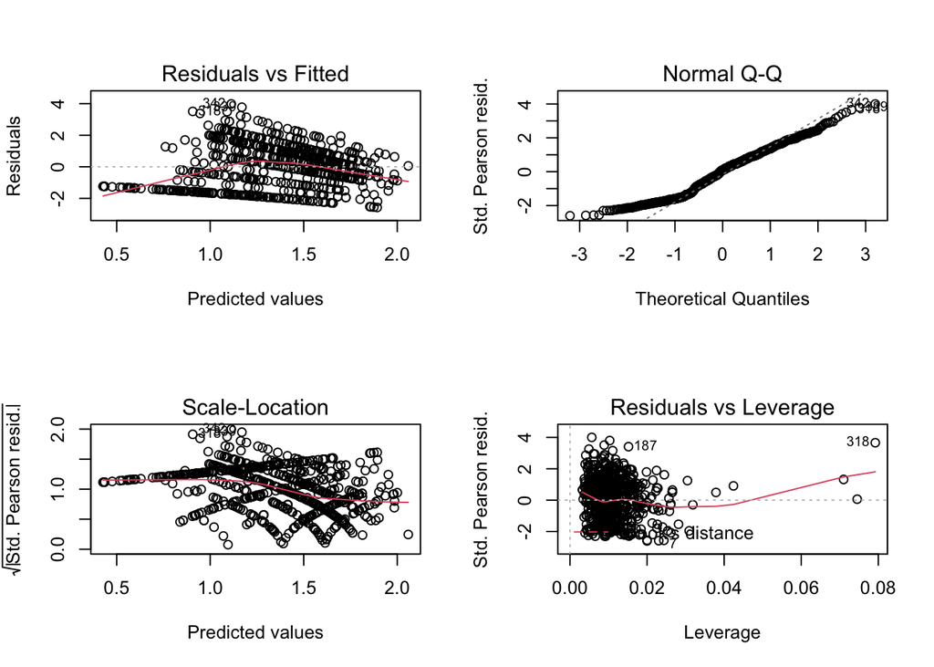

```r
#check normality, still need to do this??
par(mfrow = c(2, 2))
plot(acer_mod_poi) #check for normality
```

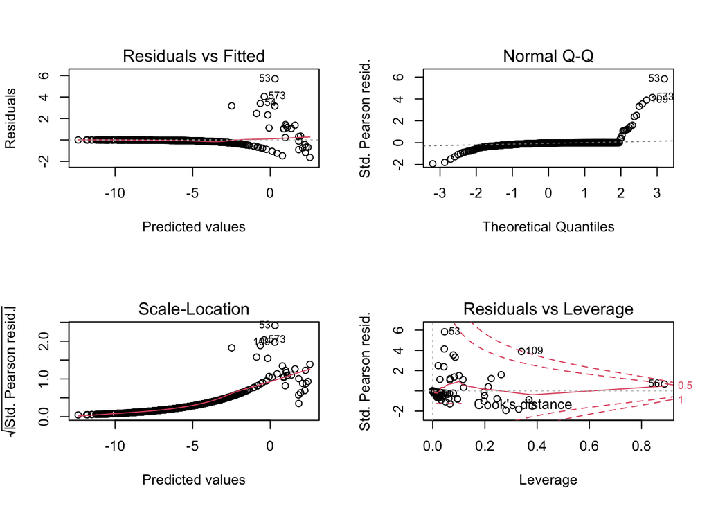

```r
plot(abies_mod_poi) #check for normality
```

```r
#assessing degree of variation explained: pseudo r^2
  #pseudo r^2: a measure of improvement over the null model in terms of LL and thus give an indication of goodness of fit

acer_poi_pseudo_r2 <- (1 - acer_mod_poi$deviance/acer_mod_poi$null.deviance)
print(acer_poi_pseudo_r2)
```

```
## [1] 0.1342074
```

```r
abies_poi_pseudo_r2 <- (1 - abies_mod_poi$deviance/abies_mod_poi$null.deviance)
print(abies_poi_pseudo_r2)
```

```
## [1] 0.8951796
```

- how well does the exploratory model appear to explain cover?

Acer:The exploratory model’s pseudo r-squared value is 0.13, indicating that 13% of the variability observed in cover is explained by the model. Abies: The exploratory model’s pseudo r-squared value is 0.90, indicating that 90% of the variability observed in cover is explained by the model.

- which explanatory variables are the most important?

Acer: Similar to the LM, Elevation, TCI (water potential), disturbance and beers all generated statistically significant results.

Abies: Similar to the LM, elevation, stream distance and disturbance all generated statistically significant results. The GLM also calculated a statistically significant result for TCI.

- do model diagnostics indicate any problems with violations of OLS assumptions?

Acer: Similar to the LM, the residuals vs. fitted and the Scale-Location graphs show some strange geometric patterns, which indicates issues with homoscedasticity. The Q-Q plot shows that the points are pretty much normally distributed, except for the same few points as in the lm model.The Residuals vs Leverage graph indicates that there are large outliers that are having a disproportionate effect on the regression (points 318, 7, and 187).

Abies: The residuals vs. fitted and scale-location graphs have spikes of points towards the right hand side of the graphs, indicating issues with homoscedasticity. However, I would say that the graphs look less extreme in the GLM than the LM. The Q-Q plot shows some issues with normality. The Residuals vs Leverage graph shows some large outliers that are strongly effecting the regression, but points look more evenly distributed in the GLM than the LM.

- are you able to explain variance in one species better than another, why might this be the case?

For Acer, the pseudo r^2 is 0.13 (which is similar to the LM) and the pseudo r^2 for Abies is 0.90 (much different from the LM). Variance is better explained for Abies than Acer using a GLM because the pseudo r^2 is 9.0, indicating a high goodness of fit for the GLM Aibes model (pseudo r^2 ranges from 0-1). This might be the case because Abies has many 0 cover sites, which the LM (Gaussian error) predicts as negative cover in which the GLM (Poisson error) does not.

*Compare your qualitative assessment of which variables were most important in each model. Does it appear that changing the error distribution changed the results much? In what ways?

3. Provide a plain English summary (i.e., no statistics) of what you have found and what conclusions we can take away from your analysis?

Cover of both Abies and Acer is best explained as a function of elevation. This makes biological sense because Acer is a habitat generalist that is happy growing in ranges from sea level to 3,000 feet (https://www.srs.fs.usda.gov/pubs/misc/ag_654/volume_2/acer/rubrum.htm) while Abies is typically found at higher elevations ranging from 4,500-6,600 feet (https://www.fs.usda.gov/database/feis/plants/tree/abifra/all.html).

4. (optional) Examine the behavior of the function `stepAIC()` using the exploratory models developed above. This is a very simple and not very robust machine learning stepwise algorithm that uses AIC to select a best model. By default it does a backward selection routine.

```r
#install.packages("MASS")
library(MASS)
stepAIC(acer_mod_lm)
```

```
## Start:  AIC=1353.75
## cover ~ elev + tci + streamdist + disturb + beers
##
##              Df Sum of Sq    RSS    AIC
## - streamdist  1     10.85 4552.6 1353.5
## <none>                    4541.7 1353.8
## - disturb     3     44.06 4585.8 1354.8
## - beers       1     55.14 4596.8 1360.6
## - tci         1     55.84 4597.5 1360.7
## - elev        1    664.13 5205.8 1451.9
##
## Step:  AIC=1353.5
## cover ~ elev + tci + disturb + beers
##
##           Df Sum of Sq    RSS    AIC
## <none>                 4552.6 1353.5
## - disturb  3     42.74 4595.3 1354.4
## - beers    1     55.72 4608.3 1360.4
## - tci      1     69.58 4622.1 1362.6
## - elev     1    670.27 5222.8 1452.3
```

```
##
## Call:
## lm(formula = cover ~ elev + tci + disturb + beers, data = acer)
##
## Coefficients:
##   (Intercept)           elev            tci  disturbLT-SEL  disturbSETTLE
##      8.844732      -0.003339      -0.143822      -0.404681      -0.922722
## disturbVIRGIN          beers
##     -0.336012      -0.412296
```

```r
#AIC is 1353
stepAIC(acer_mod_poi)
```

```
## Start:  AIC=3651.86
## cover ~ elev + tci + streamdist + disturb + beers
##
##              Df Deviance    AIC
## - streamdist  1   1661.5 3651.3
## <none>            1660.1 3651.9
## - disturb     3   1672.6 3658.4
## - beers       1   1672.3 3662.0
## - tci         1   1674.5 3664.3
## - elev        1   1831.7 3821.4
##
## Step:  AIC=3651.31
## cover ~ elev + tci + disturb + beers
##
##           Df Deviance    AIC
## <none>         1661.5 3651.3
## - disturb  3   1674.0 3657.8
## - beers    1   1674.0 3661.7
## - tci      1   1678.7 3666.4
## - elev     1   1836.0 3823.8
```

```
##
## Call:  glm(formula = cover ~ elev + tci + disturb + beers, family = "poisson",
##     data = acer)
##
## Coefficients:
##   (Intercept)           elev            tci  disturbLT-SEL  disturbSETTLE
##     2.6183396     -0.0008972     -0.0363643     -0.1216361     -0.2358882
## disturbVIRGIN          beers
##    -0.0993090     -0.0960118
##
## Degrees of Freedom: 733 Total (i.e. Null);  727 Residual
## Null Deviance:       1917
## Residual Deviance: 1662  AIC: 3651
```

```r
#AIC is 3651, therefore lm model is a better fit than poisson.

stepAIC(abies_mod_lm)
```

```
## Start:  AIC=-114.02
## cover ~ elev + tci + streamdist + disturb + beers
##
##              Df Sum of Sq    RSS      AIC
## - beers       1     1.497 616.35 -114.231
## <none>                    614.85 -114.016
## - tci         1     2.108 616.96 -113.503
## - streamdist  1     3.976 618.82 -111.284
## - disturb     3    28.398 643.25  -86.874
## - elev        1    98.133 712.98   -7.325
##
## Step:  AIC=-114.23
## cover ~ elev + tci + streamdist + disturb
##
##              Df Sum of Sq    RSS      AIC
## <none>                    616.35 -114.231
## - tci         1     2.400 618.75 -113.378
## - streamdist  1     4.034 620.38 -111.442
## - disturb     3    29.116 645.46  -86.350
## - elev        1    96.644 712.99   -9.317
```

```
##
## Call:
## lm(formula = cover ~ elev + tci + streamdist + disturb, data = abies)
##
## Coefficients:
##   (Intercept)           elev            tci     streamdist  disturbLT-SEL
##    -1.6330320      0.0013127      0.0272317      0.0004586      0.3125086
## disturbSETTLE  disturbVIRGIN
##     0.5555838      0.5583170
```

```r
#AIC is 114
stepAIC(abies_mod_poi)
```

```
## Start:  AIC=203.75
## cover ~ elev + tci + streamdist + disturb + beers
##
##              Df Deviance    AIC
## - beers       1    98.58 201.76
## <none>             98.57 203.75
## - tci         1   105.91 209.09
## - streamdist  1   106.20 209.38
## - disturb     3   120.46 219.64
## - elev        1   519.40 622.58
##
## Step:  AIC=201.76
## cover ~ elev + tci + streamdist + disturb
##
##              Df Deviance    AIC
## <none>             98.58 201.76
## - streamdist  1   106.84 208.02
## - tci         1   107.65 208.83
## - disturb     3   120.50 217.68
## - elev        1   521.97 623.15
```

```
##
## Call:  glm(formula = cover ~ elev + tci + streamdist + disturb, family = "poisson",
##     data = abies)
##
## Coefficients:
##   (Intercept)           elev            tci     streamdist  disturbLT-SEL
##    -15.676816       0.007853       0.171748      -0.001710       1.614142
## disturbSETTLE  disturbVIRGIN
##      3.171190       2.646177
##
## Degrees of Freedom: 733 Total (i.e. Null);  727 Residual
## Null Deviance:       940.4
## Residual Deviance: 98.58     AIC: 201.8
```

```r
#AIC is 202, therefore the lm model is a better fit than poisson.
```

5. (optional) Develop a model for the number of species in each site (i.e., unique plotID). This variable will also be discrete so the Poisson may be a good starting approximation. Side note: the Poisson distribution converges asymptotically on the Gaussian distribution as the mean of the distribution increases. Thus Poisson regression does not differ much from traditional OLS when means are large.